# ML LAB 08 - SINGLE AND COMPLETE LINK

### Name : Tulasi Raman R

### Register Number : 21MIS1170

# Importing Libraries

```python
import numpy as np
import pandas as pd
import matplotlib.pyplot as plt
%matplotlib inline
import scipy.cluster.hierarchy as shc
from scipy.spatial.distance import squareform, pdist
```

# Generate Dataset

```python
a = np.random.random_sample(size = 10)
b = np.random.random_sample(size = 10)
point = ['P1','P2','P3','P4','P5','P6','P7','P8','P9','P10']
df = pd.DataFrame({'Point':point, 'a':np.round(a,2), 'b':np.round(b,2)})
df = df.set_index('Point')
df
```

| Point | a | b |
| --- | --- | --- |
| P1 | 0.68 | 0.88 |
| P2 | 0.38 | 0.08 |
| P3 | 0.27 | 0.23 |
| P4 | 0.77 | 0.97 |
| P5 | 0.53 | 0.90 |
| P6 | 0.03 | 0.90 |
| P7 | 0.76 | 0.77 |
| P8 | 0.80 | 0.53 |
| P9 | 0.44 | 0.53 |
| P10 | 0.74 | 0.52 |

```python
df.info()
```

```
<class 'pandas.core.frame.DataFrame'>
Index: 10 entries, P1 to P10
Data columns (total 2 columns):
 #   Column  Non-Null Count  Dtype
---  ------  --------------  -----
 0   a       10 non-null     float64
 1   b       10 non-null     float64
dtypes: float64(2)
memory usage: 540.0+ bytes
```

# Visualizing the Dataset

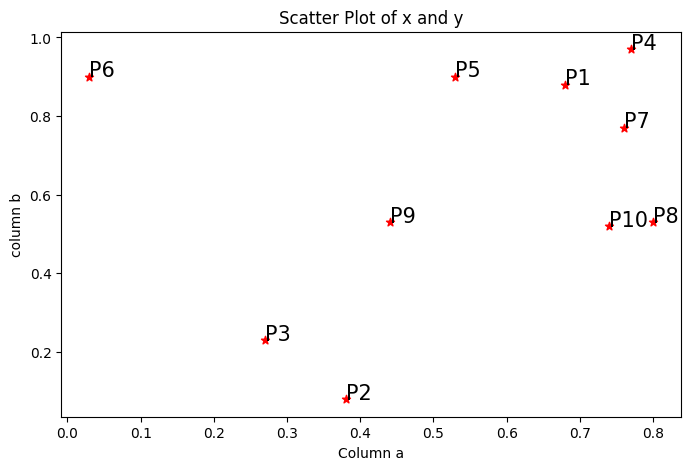

```python
plt.figure(figsize=(8,5))
plt.scatter(df['a'], df['b'], c='r', marker='*')
plt.xlabel('Column a')
plt.ylabel('column b')
plt.title('Scatter Plot of x and y')
for j in df.itertuples():
    plt.annotate(j.Index, (j.a, j.b), fontsize=15)
```

# Calculating Euclidean Distance Between Each Point

```python
dist = pd.DataFrame(squareform(pdist(df[['a','b']]), 'euclidean'), columns = df.index.values, index = df.index.values)
dist
```

|  | P1 | P2 | P3 | P4 | P5 | P6 | P7 | P8 | P9 | P10 |
| --- | --- | --- | --- | --- | --- | --- | --- | --- | --- | --- |
| P1 | 0.000000 | 0.854400 | 0.768505 | 0.127279 | 0.151327 | 0.650308 | 0.136015 | 0.370000 | 0.424382 | 0.364966 |
| P2 | 0.854400 | 0.000000 | 0.186011 | 0.971700 | 0.833607 | 0.891572 | 0.787718 | 0.615549 | 0.453982 | 0.568507 |
| P3 | 0.768505 | 0.186011 | 0.000000 | 0.893085 | 0.718679 | 0.711688 | 0.729178 | 0.609016 | 0.344819 | 0.552268 |
| P4 | 0.127279 | 0.971700 | 0.893085 | 0.000000 | 0.250000 | 0.743303 | 0.200250 | 0.441022 | 0.550000 | 0.450999 |
| P5 | 0.151327 | 0.833607 | 0.718679 | 0.250000 | 0.000000 | 0.500000 | 0.264197 | 0.458039 | 0.380789 | 0.434166 |
| P6 | 0.650308 | 0.891572 | 0.711688 | 0.743303 | 0.500000 | 0.000000 | 0.741485 | 0.854283 | 0.552268 | 0.805295 |
| P7 | 0.136015 | 0.787718 | 0.729178 | 0.200250 | 0.264197 | 0.741485 | 0.000000 | 0.243311 | 0.400000 | 0.250799 |
| P8 | 0.370000 | 0.615549 | 0.609016 | 0.441022 | 0.458039 | 0.854283 | 0.243311 | 0.000000 | 0.360000 | 0.060828 |
| P9 | 0.424382 | 0.453982 | 0.344819 | 0.550000 | 0.380789 | 0.552268 | 0.400000 | 0.360000 | 0.000000 | 0.300167 |
| P10 | 0.364966 | 0.568507 | 0.552268 | 0.450999 | 0.434166 | 0.805295 | 0.250799 | 0.060828 | 0.300167 | 0.000000 |

# Single Linkage Clustering

### Interpretation from Euclidean Distance for Single Link

- Notice that Point(P8,P10) is having the the least distance of all with 0.060828, so we'll conclude these both clusters as neighbouring clusters. So initially we'll merge those two points together considering the least distance between the cluster pointer which is again 0.060828. Then the next least distance is (P1, P4) with 0.127279, so we'll merge those two neighbouring clusters by calculating the minimum distance between cluster points which is again 0.127279 as we have only one point in each cluster and minimum distance have to be computed.
- Similarly calculating the least distance between each and every clusters and merging them based on the minimum distance between the neighbouring clusters is called Single Linkage Clustering. This iterative process continues until all data points are clustered, revealing patterns in the data.

```python
 def single_linkage(dist_matrix):
    n = len(dist_matrix)
    while n > 1:
        min_val = float('inf')
        min_index = None
        for i in range(n):
            for j in range(i+1, n):
                if dist_matrix.iloc[i, j] < min_val and dist_matrix.index[i] != dist_matrix.columns[j]:
                    min_val = dist_matrix.iloc[i, j]
                    min_index = (i, j)

        if min_val == float('inf'):
            break

        i, j = min_index
        cluster1, cluster2 = dist_matrix.index[i], dist_matrix.columns[j]
        print(f'Merging clusters {cluster1} and {cluster2} with distance {min_val}')

        new_cluster = f'({cluster1},{cluster2})'

        dist_matrix[new_cluster] = dist_matrix[[cluster1, cluster2]].min(axis=1)
        dist_matrix.loc[new_cluster] = dist_matrix.loc[[cluster1, cluster2]].min(axis=0)
        dist_matrix = dist_matrix.drop([cluster1, cluster2], axis=0)
        dist_matrix = dist_matrix.drop([cluster1, cluster2], axis=1)
        n -= 1

        print(dist_matrix)
        print("")
 print("Single-Link Clustering:")
 single_linkage(dist.copy())
```

```
Single-Link Clustering:
Merging clusters P8 and P10 with distance 0.060827625302982254
                P1        P2        P3        P4        P5        P6  \
P1        0.000000  0.854400  0.768505  0.127279  0.151327  0.650308
P2        0.854400  0.000000  0.186011  0.971700  0.833607  0.891572
P3        0.768505  0.186011  0.000000  0.893085  0.718679  0.711688
P4        0.127279  0.971700  0.893085  0.000000  0.250000  0.743303
P5        0.151327  0.833607  0.718679  0.250000  0.000000  0.500000
P6        0.650308  0.891572  0.711688  0.743303  0.500000  0.000000
P7        0.136015  0.787718  0.729178  0.200250  0.264197  0.741485
P9        0.424382  0.453982  0.344819  0.550000  0.380789  0.552268
(P8,P10)  0.364966  0.568507  0.552268  0.441022  0.434166  0.805295

                P7        P9  (P8,P10)
P1        0.136015  0.424382  0.364966
P2        0.787718  0.453982  0.568507
P3        0.729178  0.344819  0.552268
P4        0.200250  0.550000  0.441022
P5        0.264197  0.380789  0.434166
P6        0.741485  0.552268  0.805295
P7        0.000000  0.400000  0.243311
P9        0.400000  0.000000  0.300167
(P8,P10)  0.243311  0.300167  0.000000

Merging clusters P1 and P4 with distance 0.12727922061357852
                P2        P3        P5        P6        P7        P9  \
P2        0.000000  0.186011  0.833607  0.891572  0.787718  0.453982
P3        0.186011  0.000000  0.718679  0.711688  0.729178  0.344819
P5        0.833607  0.718679  0.000000  0.500000  0.264197  0.380789
P6        0.891572  0.711688  0.500000  0.000000  0.741485  0.552268
P7        0.787718  0.729178  0.264197  0.741485  0.000000  0.400000
P9        0.453982  0.344819  0.380789  0.552268  0.400000  0.000000
(P8,P10)  0.568507  0.552268  0.434166  0.805295  0.243311  0.300167
(P1,P4)   0.854400  0.768505  0.151327  0.650308  0.136015  0.424382

          (P8,P10)   (P1,P4)
P2        0.568507  0.854400
P3        0.552268  0.768505
P5        0.434166  0.151327
P6        0.805295  0.650308
```

[output cut: 70 more lines]

```
(P2,P3)                                                     0.344819
(P9,((P8,P10),(P5,(P7,(P1,P4)))))                           0.000000

Merging clusters (P2,P3) and (P9,((P8,P10),(P5,(P7,(P1,P4))))) with distance 0.3448187929913334
                                              P6  \
P6                                           0.0
((P2,P3),(P9,((P8,P10),(P5,(P7,(P1,P4))))))  0.5

                                             ((P2,P3),(P9,((P8,P10),(P5,(P7,(P1,P4))))))
P6                                                                                   0.5
((P2,P3),(P9,((P8,P10),(P5,(P7,(P1,P4))))))                                          0.0

Merging clusters P6 and ((P2,P3),(P9,((P8,P10),(P5,(P7,(P1,P4)))))) with distance 0.5
                                                  (P6,((P2,P3),(P9,((P8,P10),(P5,(P7,(P1,P4)))))))
(P6,((P2,P3),(P9,((P8,P10),(P5,(P7,(P1,P4)))))))                                               0.0
```

### Visualizing Single Linkeage

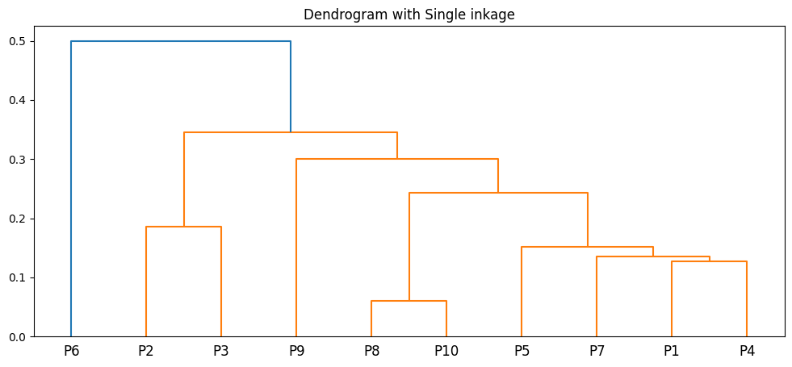

```python
plt.figure(figsize=(12,5))
plt.title("Dendrogram with Single inkage")
dend = shc.dendrogram(shc.linkage(df[['a', 'b']], method='single'), labels=df.index)
```